# Randomness

Yuanyuan Pan

October 9, 2016

This project helps understanding simulation of pseudo-random and quasi-random numbers and application of Monte Carlo method.

## Part 1. Generate uniformly distributed random numbers

### 1.1 Use runif()

Function runif(N,a,b) simulates $N$ pseudo-random numbers uniformly distributed on $[a,b]$.

```r
set.seed(15)
Sample<-runif(1000,0,1)
```

### 1.2 Simulate Uniform Random Sample on [0,1] Using Random.org.

From Random.org you can download binary sequence using library random.

This library is an interface to the web service of Random.org.

```r
library(random)
nFlips<-1000
dataFromRandom<-randomNumbers(n=nFlips, min=0, max=1, col=1, base=2, check=TRUE)
head(dataFromRandom)
```

```
##      V1
## [1,]  0
## [2,]  0
## [3,]  1
## [4,]  0
## [5,]  0
## [6,]  1
```

### Turn sequence of {0,1} into uniform random numbers on [0,1].

```r
suppressMessages(library(compositions))
```

Create function that turns a sequence of zeros and ones of length n into decimal form.

```r
bin2dec<-function(Bin.Seq){
  unbinary(paste(Bin.Seq,collapse=""))
}
bin2dec(c(1,1,1,1,1,0))
```

```
## [1] 62
```

Turn the sequence of zeros and ones dataFromRandom of length 1000 into a matrix with 10 columns and 100 rows

```r
Binary.matrix<-matrix(dataFromRandom,ncol=10)
head(Binary.matrix)
```

```
##      [,1] [,2] [,3] [,4] [,5] [,6] [,7] [,8] [,9] [,10]
## [1,]    0    1    0    0    1    1    0    0    1     1
## [2,]    0    1    1    0    1    1    1    1    0     0
## [3,]    1    0    1    1    0    0    0    0    1     1
## [4,]    0    1    1    0    0    0    0    1    1     0
## [5,]    0    0    0    1    0    1    0    1    0     0
## [6,]    1    1    0    0    0    0    1    0    0     0
```

Transform each row of the matrix into decimal format using bin2dec() and divide the numbers by $2^{10}$ to make real numbers in [0,1].

```r
Decimal.Sample<-apply(Binary.matrix,1,bin2dec)/2^10
Decimal.Sample
```

```
##   [1] 0.2998046875 0.4335937500 0.6904296875 0.3808593750 0.0820312500
##   [6] 0.7578125000 0.8847656250 0.8017578125 0.3037109375 0.1015625000
##  [11] 0.3583984375 0.6542968750 0.6806640625 0.4335937500 0.4013671875
##  [16] 0.0009765625 0.0625000000 0.7617187500 0.0058593750 0.0000000000
##  [21] 0.4462890625 0.5556640625 0.4121093750 0.6191406250 0.0058593750
##  [26] 0.0244140625 0.0400390625 0.9814453125 0.7050781250 0.3779296875
##  [31] 0.1591796875 0.5273437500 0.7402343750 0.4443359375 0.3603515625
##  [36] 0.9882812500 0.6953125000 0.9375000000 0.0869140625 0.0019531250
##  [41] 0.7890625000 0.3281250000 0.9091796875 0.5371093750 0.2988281250
##  [46] 0.2382812500 0.9697265625 0.2880859375 0.3837890625 0.3222656250
##  [51] 0.9687500000 0.0800781250 0.9960937500 0.8525390625 0.5156250000
##  [56] 0.8164062500 0.2656250000 0.3730468750 0.5498046875 0.3476562500
##  [61] 0.0839843750 0.8925781250 0.8818359375 0.8242187500 0.9404296875
##  [66] 0.5253906250 0.6093750000 0.2324218750 0.3408203125 0.8310546875
##  [71] 0.6347656250 0.1259765625 0.6914062500 0.5634765625 0.4443359375
##  [76] 0.9199218750 0.8261718750 0.4902343750 0.5781250000 0.6757812500
##  [81] 0.0947265625 0.6435546875 0.9833984375 0.8603515625 0.0449218750
##  [86] 0.0742187500 0.9472656250 0.9736328125 0.6757812500 0.4111328125
##  [91] 0.7900390625 0.4863281250 0.4833984375 0.3066406250 0.1240234375
##  [96] 0.5078125000 0.4892578125 0.6992187500 0.0869140625 0.9970703125
```

All numbers in Decimal.Sample are between 0 and 1. This is your own equivalent of the sample obtained by runif().

## Part 2. Test random number generator

### 2.1 Test uniformity of distribution of both random number generators

#### 2.1.1. Sample obtained by runif()

Analyze what was simulated by first looking at the histogram.

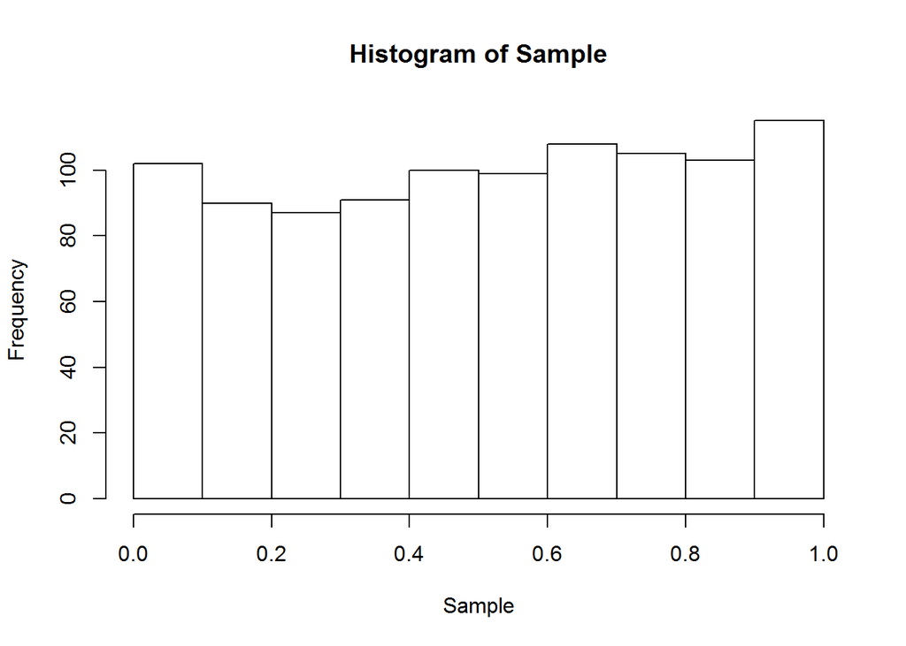

```r
Sample.histogram<-hist(Sample)
```

```r
Sample.histogram
```

```
## $breaks
##  [1] 0.0 0.1 0.2 0.3 0.4 0.5 0.6 0.7 0.8 0.9 1.0
##
## $counts
##  [1] 102  90  87  91 100  99 108 105 103 115
##
## $density
##  [1] 1.02 0.90 0.87 0.91 1.00 0.99 1.08 1.05 1.03 1.15
##
## $mids
##  [1] 0.05 0.15 0.25 0.35 0.45 0.55 0.65 0.75 0.85 0.95
##
## $xname
## [1] "Sample"
##
## $equidist
## [1] TRUE
##
## attr(,"class")
## [1] "histogram"
```

**This histogram tell me that the thii distribution is close to a uniform distribution. It is consistent with the goal of simulation**

Estimate mean and standard deviation of Sample.histogram$density.

```r
(Sample.histogram.mean<-mean(Sample.histogram$density))
```

```
## [1] 1
```

```r
(Sample.histogram.sd<-sd(Sample.histogram$density))
```

```
## [1] 0.08679478
```

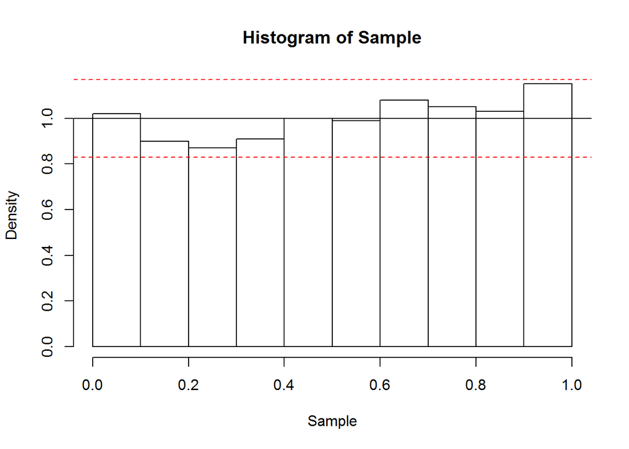

```r
plot(Sample.histogram,freq=FALSE)
abline(h=Sample.histogram.mean)
abline(h=Sample.histogram.mean+1.96*Sample.histogram.sd,col="red",lty=2)
abline(h=Sample.histogram.mean-1.96*Sample.histogram.sd,col="red",lty=2)
```

**This graph tell me that all the value of intervals is within the mean’s confidential interval.**

Estimate moments of Sample.

```r
(Sample.mean<-mean(Sample))
```

```
## [1] 0.5161848
```

```r
(Sample.variance<-var(Sample))
```

```
## [1] 0.08413663
```

Check the summary of the simulated sample.

```r
summary(Sample)
```

```
##      Min.   1st Qu.    Median      Mean   3rd Qu.      Max.
## 0.0000127 0.2678000 0.5210000 0.5162000 0.7620000 0.9980000
```

** I think the best way of estimating uniform distribution over unknown interval is using the maximum and minimun of the sample**

#### 2.1.2. Repeat the same steps to test uniformity of the sample created from Random.org data.

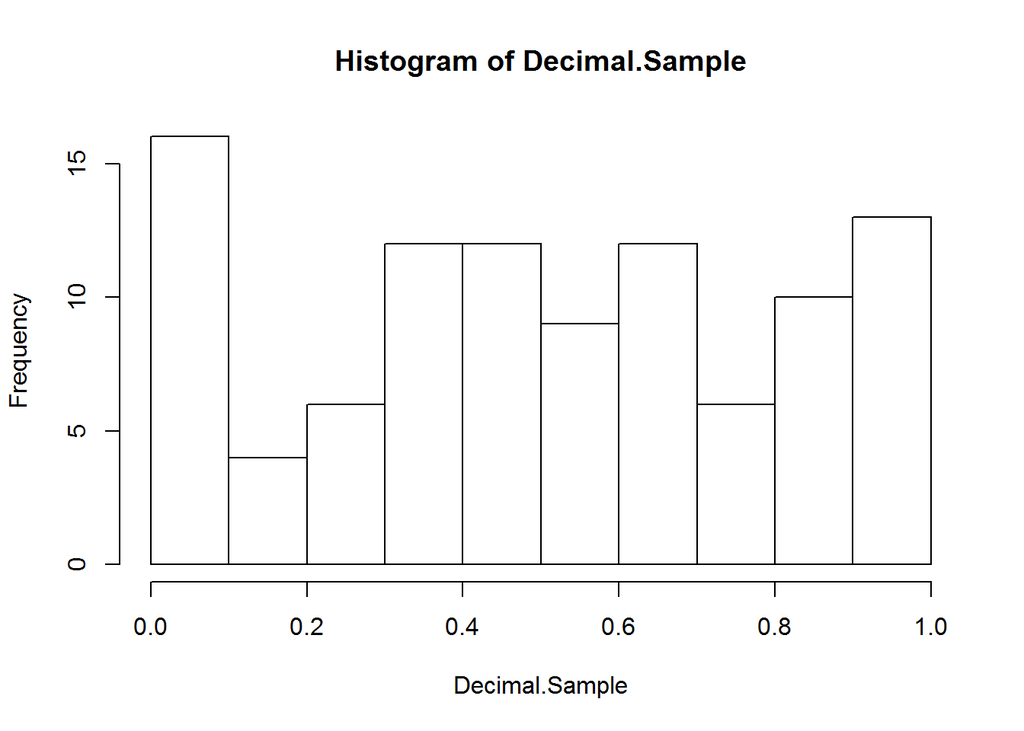

```r
Sample.histogram <- hist(Decimal.Sample)
```

```r
(Sample.histogram.mean<-mean(Sample.histogram$density))
```

```
## [1] 1
```

```r
(Sample.histogram.sd<-sd(Sample.histogram$density))
```

```
## [1] 0.3741657
```

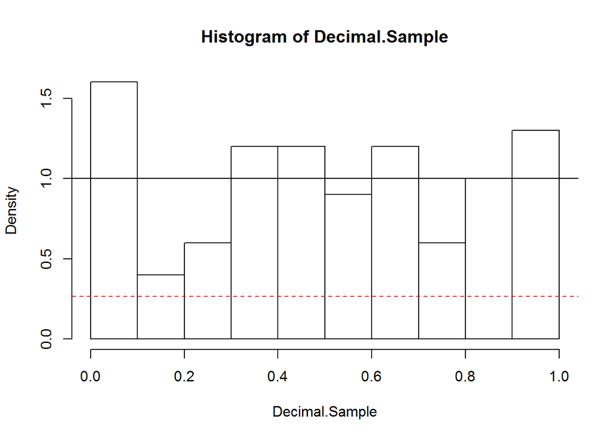

```r
plot(Sample.histogram,freq=FALSE)
abline(h=Sample.histogram.mean)
abline(h=Sample.histogram.mean+1.96*Sample.histogram.sd,col="red",lty=2)
abline(h=Sample.histogram.mean-1.96*Sample.histogram.sd,col="red",lty=2)
```

```r
(Sample.mean<-mean(Decimal.Sample))
```

```
## [1] 0.5082715
```

```r
(Sample.variance<-var(Decimal.Sample))
```

```
## [1] 0.09333964
```

### 2.2. Test independence of the sequence of zeros and ones

#### Turning point test

Turning point test is used to check if a sequence of numbers is i.i.d. (independent identically distributed). The test is based on the number of turning points in the sequence. The number of turning points is the number of maxima and minima in the series. Let $T$ be the number of turning points in a sample of length $n$ large enough. Then the statistic of the test
$$z=\frac{T-\frac{2n-4}{3}}{\sqrt{\frac{16n-29}{90}}}$$
has standard normal distribution.

The test is performed by turning.point.test() in package randtests

```r
library(randtests)
turning.point.test(Decimal.Sample)
```

```
##
##  Turning Point Test
##
## data:  Decimal.Sample
## statistic = -1.2765, n = 100, p-value = 0.2018
## alternative hypothesis: non randomness
```

The null hypothesis tested by turning point test is randomness (i.i.d.). The alternative is serial correlation in the sequence. Thus, if the test returns a very small p-value the randomness needs to be rejected.

### 2.3. Test frequency by Monobit test

To perform Monobit test you need to transform your {0,1} sample into {-1,1}. Illustrate the test on the sequence simulated in the previous lecture.

We created the sequence of coin tosses:

```r
dataFromRandom.plusminus1<-(dataFromRandom-.5)*2
```

Recall from the lecture notes that monobit test of randomness is based on the statistic

$$S=\frac{|\sum_{i=1}^{N}R_i|}{\sqrt{2N}} \sim erfc,$$

where $R_i$ is the i-th random number, summation is done over all $N=nFlips$ random numbers.

erfc is the complimentary error function, a special function complimentary to error function erf=1-erfc.

Both functions can be easily calculated in R with the help of pnorm:

```r
erf <- function(x) 2 * pnorm(x * sqrt(2)) - 1
erfc <- function(x) 2 * pnorm(x * sqrt(2), lower = FALSE)
```

The complimentary error function looks like:

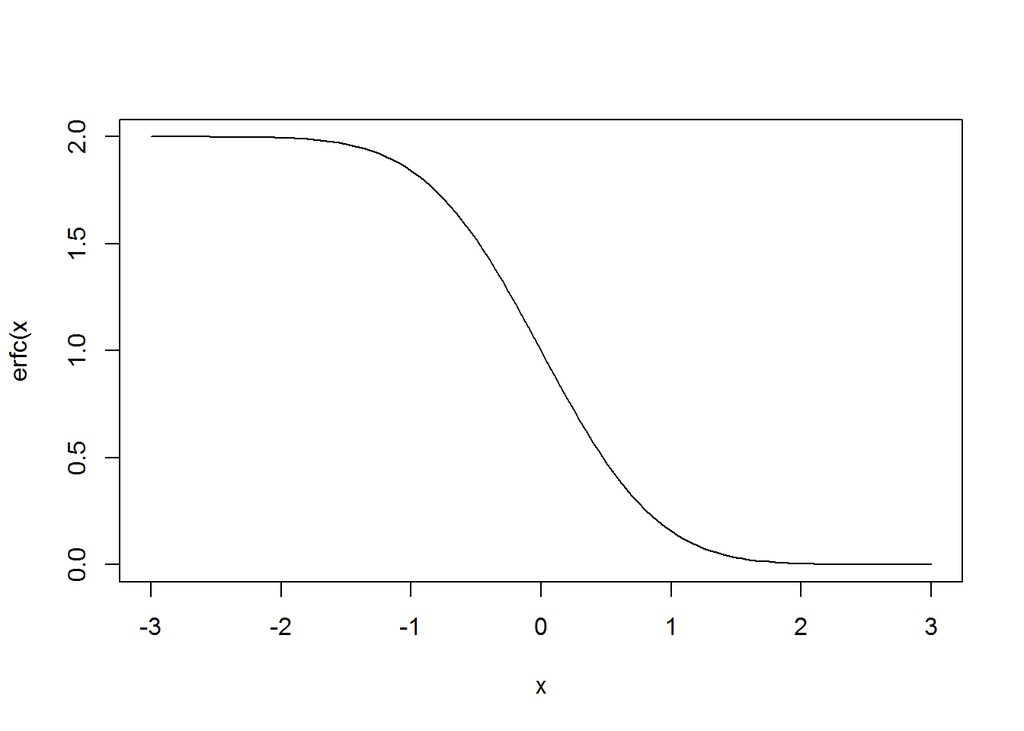

```r
plot(seq(from=-3,to=3,by=.05),erfc(seq(from=-3,to=3,by=.05)),type="l",xlab="x",ylab="erfc(x")
```

To test the sequence $R_i$ check the value erfc(S).

If the P-value or erfc(S) is less or equal than 0.01 the sequence fails the test.

```r
erfc(abs(sum(dataFromRandom.plusminus1)/sqrt(2*nFlips)))
```

```
## [1] 0.1641035
```

The test shows that our sequence passes.

Now check each of the sub-sequences created earlier:

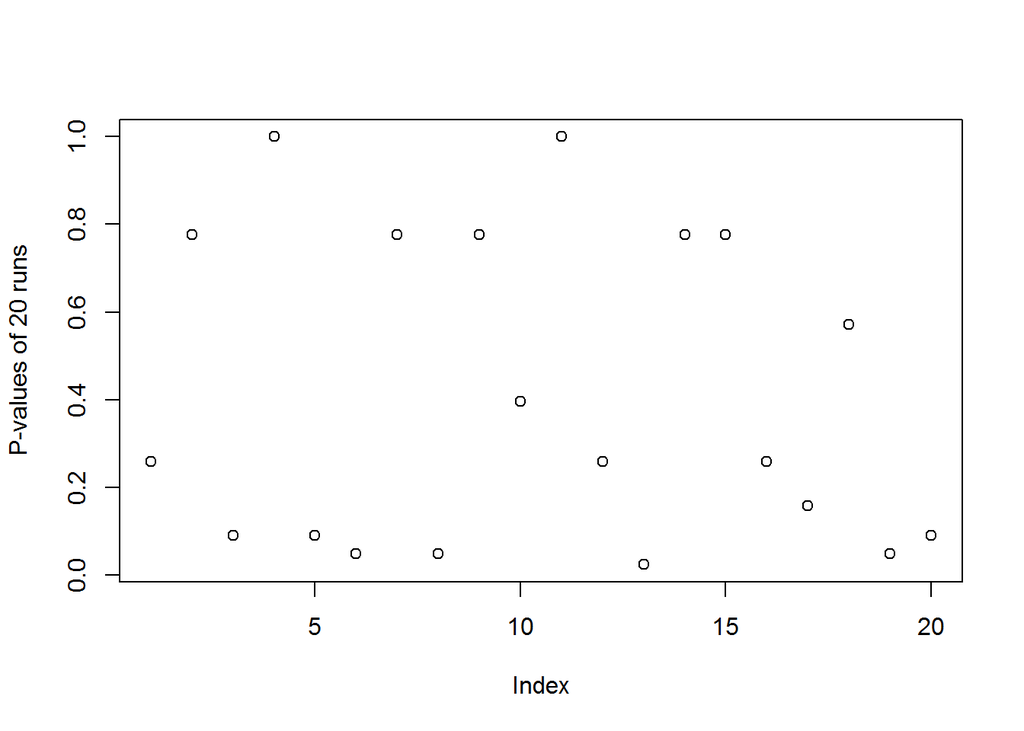

```r
plot(erfc(abs(apply(matrix(dataFromRandom.plusminus1,ncol=50),1,sum))/sqrt(2*50)),ylab="P-values of 20 runs")
```

How many runs out of 20 fail the test?

```r
sum(erfc(abs(apply(matrix(dataFromRandom.plusminus1,ncol=50),1,sum))/sqrt(2*50))<=.01)
```

```
## [1] 0
```

## Part 3. Invent a random number generator

Think about possible sources of true or pseudo-random sequences of {0,1} and choose one or two of them. Conduct the tests described in the previous section.

### 1 Random number generator

Get the total rides of Chicago CTA buses everyday. If the the number is odd, generate 1; while if the number is even, generate 0. Then transform it to uniform distrubution using the method above.

### 2 Generate and transform random numbers

Firstly, download the bus riding information from “https://data.cityofchicago.org/Transportation/CTA-Ridership-Daily-Boarding-Totals/6iiy-9s97”

```r
Bus <- read.csv("CTA.csv")
Sample_Yuanyuan <- Bus$bus %% 2
head(Sample_Yuanyuan)
```

```
## [1] 0 1 1 1 0 1
```

```r
suppressMessages(library(compositions))
bin2dec<-function(Bin.Seq){
  unbinary(paste(Bin.Seq,collapse=""))
}
Binary.matrix<-matrix(Sample_Yuanyuan[2001:3000],ncol=10)
head(Binary.matrix)
```

```
##      [,1] [,2] [,3] [,4] [,5] [,6] [,7] [,8] [,9] [,10]
## [1,]    1    1    1    0    1    1    0    0    0     1
## [2,]    1    0    0    0    1    1    0    1    0     0
## [3,]    1    1    1    1    1    0    0    0    1     0
## [4,]    1    0    1    1    0    1    0    1    0     1
## [5,]    0    1    0    0    0    0    0    1    0     0
## [6,]    1    0    0    0    0    0    0    0    1     1
```

```r
Decimal.Sample<-apply(Binary.matrix,1,bin2dec)/2^10
Decimal.Sample
```

```
##   [1] 0.922851562 0.550781250 0.970703125 0.708007812 0.253906250
##   [6] 0.502929688 0.502929688 0.209960938 0.986328125 0.846679688
##  [11] 0.364257812 0.367187500 0.892578125 0.408203125 0.968750000
##  [16] 0.981445312 0.303710938 0.985351562 0.010742188 0.060546875
##  [21] 0.212890625 0.079101562 0.110351562 0.531250000 0.855468750
##  [26] 0.509765625 0.262695312 0.080078125 0.388671875 0.327148438
##  [31] 0.847656250 0.558593750 0.583007812 0.567382812 0.452148438
##  [36] 0.482421875 0.791992188 0.615234375 0.536132812 0.360351562
##  [41] 0.811523438 0.456054688 0.035156250 0.518554688 0.651367188
##  [46] 0.731445312 0.845703125 0.178710938 0.665039062 0.124023438
##  [51] 0.187500000 0.415039062 0.494140625 0.041992188 0.496093750
##  [56] 0.589843750 0.893554688 0.297851562 0.447265625 0.294921875
##  [61] 0.655273438 0.804687500 0.487304688 0.683593750 0.776367188
##  [66] 0.708007812 0.687500000 0.826171875 0.277343750 0.132812500
##  [71] 0.058593750 0.458984375 0.480468750 0.497070312 0.276367188
##  [76] 0.565429688 0.215820312 0.512695312 0.284179688 0.729492188
##  [81] 0.142578125 0.433593750 0.397460938 0.015625000 0.435546875
##  [86] 0.540039062 0.902343750 0.807617188 0.747070312 0.643554688
##  [91] 0.622070312 0.720703125 0.943359375 0.350585938 0.004882812
##  [96] 0.229492188 0.382812500 0.502929688 0.281250000 0.771484375
```

### 3 Test the uniform

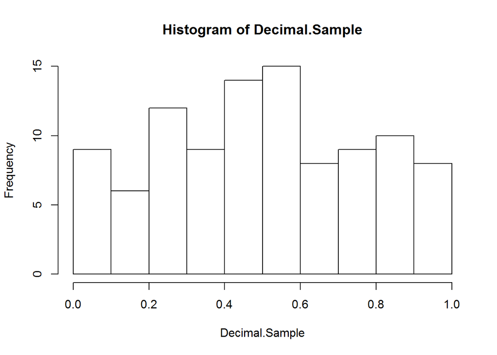

```r
Sample.histogram <- hist(Decimal.Sample)
```

```r
(Sample.histogram.mean<-mean(Sample.histogram$density))
```

```
## [1] 1
```

```r
(Sample.histogram.sd<-sd(Sample.histogram$density))
```

```
## [1] 0.2828427
```

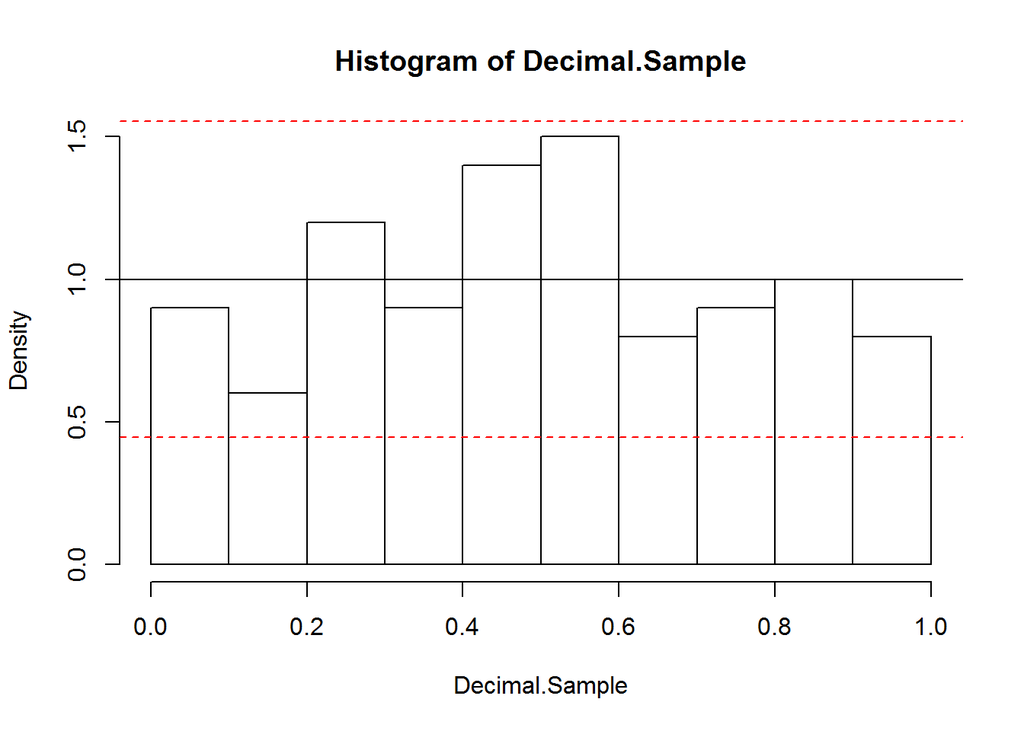

```r
plot(Sample.histogram,freq=FALSE)
abline(h=Sample.histogram.mean)
abline(h=Sample.histogram.mean+1.96*Sample.histogram.sd,col="red",lty=2)
abline(h=Sample.histogram.mean-1.96*Sample.histogram.sd,col="red",lty=2)
```

This transformed random numbers can be taken as uniform distrubution.

### 4 Frequency test

```r
Sample.plusminus1 <- (Sample_Yuanyuan[2001:3000]-.5)*2
erf <- function(x) 2 * pnorm(x * sqrt(2)) - 1
erfc <- function(x) 2 * pnorm(x * sqrt(2), lower = FALSE)
erfc(abs(sum(Sample.plusminus1)/sqrt(2*length(Sample.plusminus1))))
```

```
## [1] 0.6128816
```

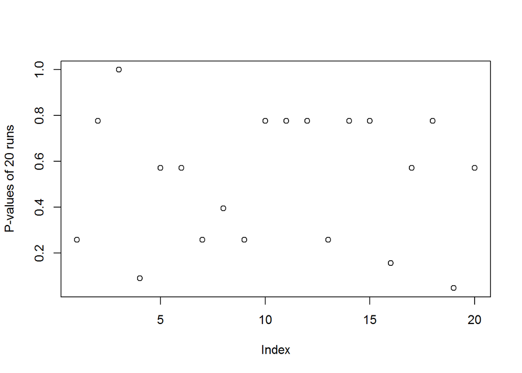

```r
plot(erfc(abs(apply(matrix(Sample.plusminus1,ncol=50),1,sum))/sqrt(2*50)),ylab="P-values of 20 runs")
```

```r
sum(erfc(abs(apply(matrix(Sample.plusminus1,ncol=50),1,sum))/sqrt(2*50))<=.01)
```

```
## [1] 0
```

### 5 Results of the turning point test

```r
turning.point.test(Decimal.Sample)
```

```
##
##  Turning Point Test
##
## data:  Decimal.Sample
## statistic = -1.3633, n = 99, p-value = 0.1728
## alternative hypothesis: non randomness
```

## Part 4. Monte Carlo Method

### 4.1. Scratch off quote of the day: fuction download

```r
datapath<-getwd()
load(file=paste(datapath,'ScratchOffMonteCarlo.rda',sep='/'))
```

### 4.2. Simulate pseudo-random poins $[x,y]$ on $[0,100] \times [0,100]$

Select a number o points nSample.

Simulate a sample of length 2*nSample from uniform distribution on [0,100] and turn it into a $(nSample \times 2)$ matrix.

```r
my.seed = 1234
set.seed(my.seed)
nSample = 1000
xy<-runif(2*nSample,0,100)
xy<-matrix(xy,ncol=2)
```

Throw nSample simulated points on square $[0,100] \times [0,100]$ to scratch off some of yellow paint.

```r
nSample<-19000
my.seed<-876543
set.seed(my.seed)
xy<-runif(2*nSample,0,100)
xy<-matrix(xy,ncol=2)
head(xy)
```

```
##          [,1]     [,2]
## [1,] 11.54568 87.89983
## [2,] 19.54321 14.93455
## [3,] 53.19823 96.79083
## [4,] 79.36958 48.73626
## [5,] 36.25658 22.51348
## [6,] 55.89727 16.36625
```

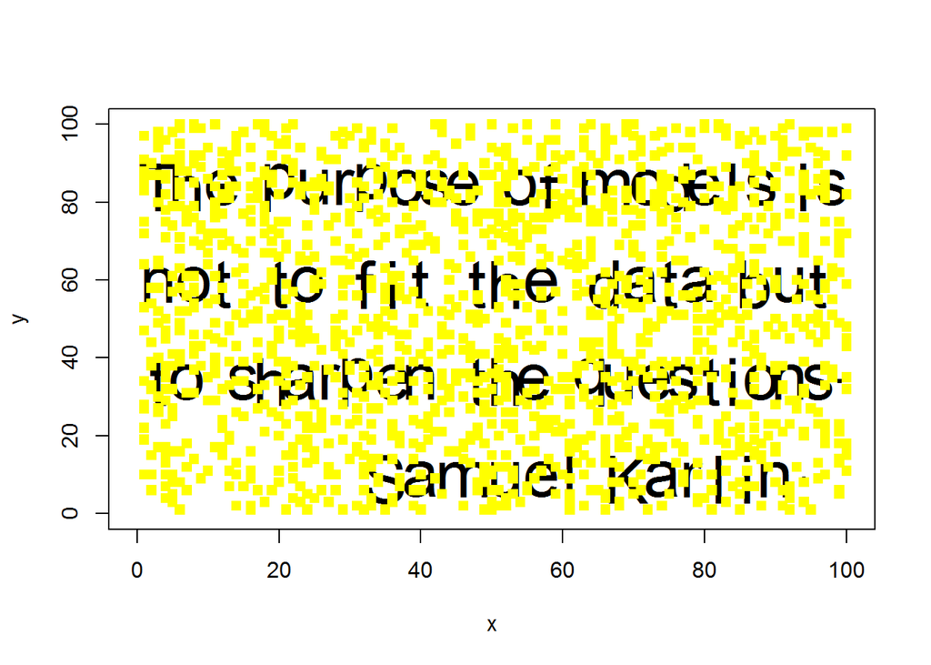

```
## [1] "Size = 19000"   "Open (%)= 85.4"
```

```r
ScratchOffMonteCarlo(xy)
```

**By changing nSample and my.seed try to make the quote of the day readable, at least 19000 sample size and 85.4% open to read the words as “THe purpose of models is not to fit the data but to sharpen the questions. - Samnuel karlin”**

### 4.3. Simulate quasi-random poins $[x,y]$ on $[0,100] \times [0,100]$

function runif() can be replaced by sobol() from library randtoolbox.

```r
library(randtoolbox)
```

Run sobol() first time with the default set for parameter init=T.

```r
my.seed<-10
set.seed(my.seed)
nSample<-10
xy<-sobol(nSample,dim=2,init=T)*100
```

Then make init=F if you want to generate different sample every time or keep it equal to T if you want repeated samples.

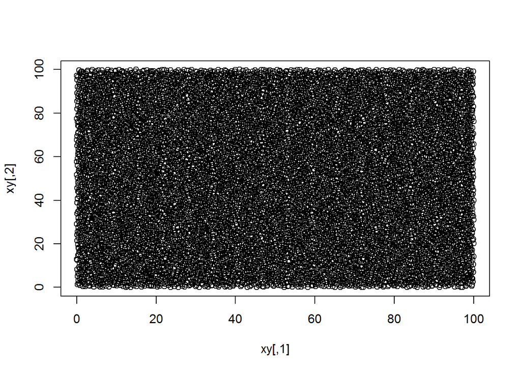

```r
my.seed <- 123
nSample<-12500
xy<-sobol(nSample,dim=2,init=T,scrambling = T,seed=my.seed)*100

plot(xy)
```

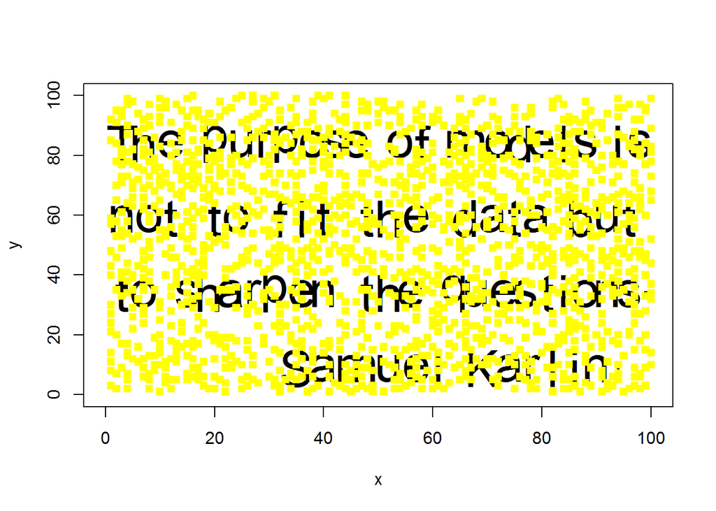

```
## [1] "Size = 12500"    "Open (%)= 85.02"
```

```r
ScratchOffMonteCarlo(xy)
```

**By changing nSample and my.seed try to make the quote of the day readable, at least 12500 sample size and 85.02% open to read the words as “THe purpose of models is not to fit the data but to sharpen the questions. - Samnuel karlin”**

The second method is faster than the first one.

Changing the sample size plays more significant role.

## Part 5. Test

```r
dataPath <- getwd()
dat <- read.csv(paste(dataPath,'Week2_Test_Sample.csv',sep="/"), header=TRUE)$x
```

Sample datNorm from normal distribution with mean dat[1] and standard deviation dat[2];

```r
datNorm <- qnorm(dat[4:503])*dat[2]+dat[1]
```

Sample datExp from exponential distribution with intensity dat[3].

```r
datExp <- qexp(dat[4:503], rate =dat[3])
```

Create matrix res with the two samples:

```r
res<-cbind(datNorm=datNorm,datExp=datExp)
```

Save res to a file and upload the file using left sidebar.

```r
write.csv(res, file = paste(dataPath,'result.csv',sep="/"), row.names = F)
```